# Programming Exercise

### Housing

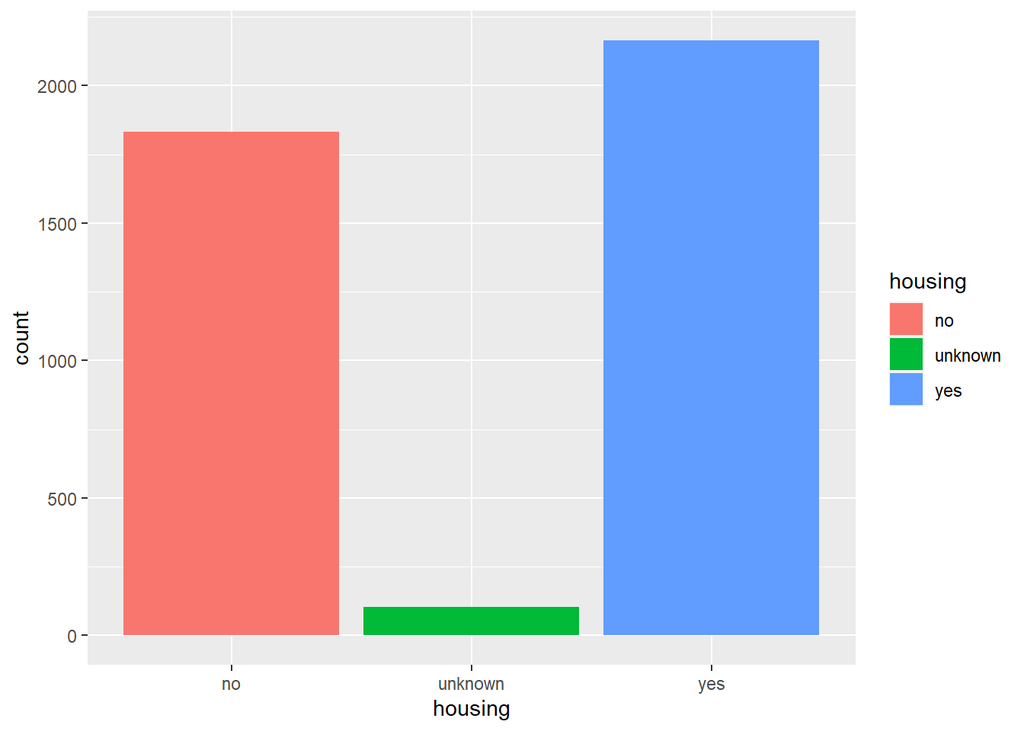

```r
ggplot(m_date, mapping=(aes(x=housing,fill=housing))) + geom_bar()
```

```r
summary(m_date$housing)
```

```
##      no unknown     yes
##    1832     104    2164
```

### loan

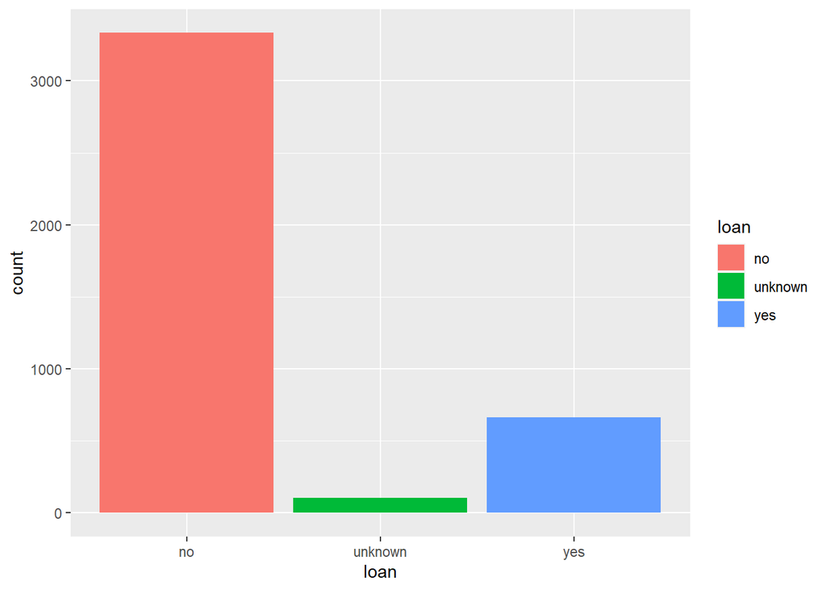

```r
ggplot(m_date, mapping=(aes(x=loan,fill=loan))) + geom_bar()
```

```r
summary(m_date$loan)
```

```
##      no unknown     yes
##    3334     104     662
```

### loan contact

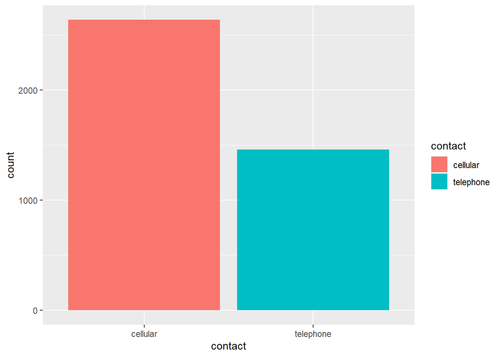

```r
ggplot(m_date, mapping=(aes(x=contact,fill=contact))) + geom_bar()
```

```r
summary(m_date$contact)
```

```
##  cellular telephone
##      2639      1461
```

- Observation
  - The graph demonstrates that there were more cellular customer contacts.

### loan month

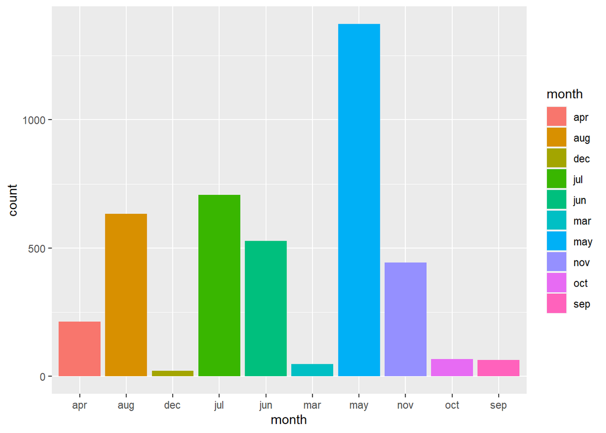

```r
ggplot(m_date, mapping=(aes(x=month,fill=month))) + geom_bar()
```

- Observation
  - The month of May saw the most contacts.
  - Decembar saw the fewest contacts made overall.

```r
summary(m_date$month)
```

```
##  apr  aug  dec  jul  jun  mar  may  nov  oct  sep
##  214  633   22  707  528   48 1373  443   68   64
```

### loan day_of_week

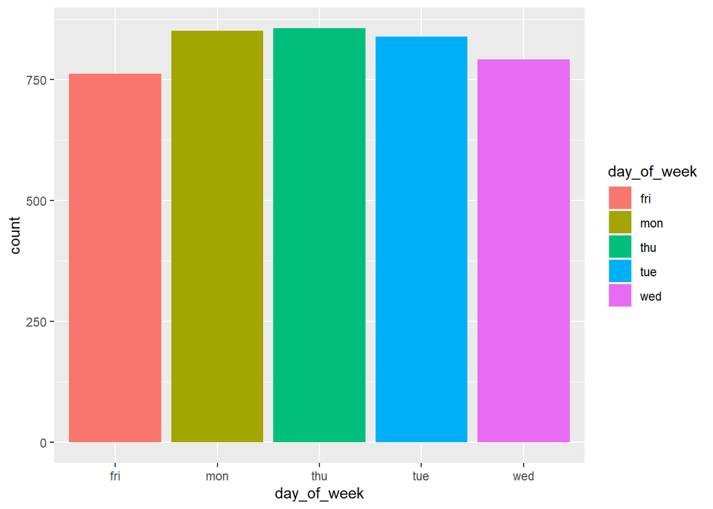

```r
ggplot(m_date, mapping=(aes(x=day_of_week,fill=day_of_week))) + geom_bar()
```

```r
summary(m_date$day_of_week)
```

```
## fri mon thu tue wed
## 762 851 856 839 792
```

- Observation
  - Normal distribution of numbers throughout the week on all days

## Part 2 Statistical modelling

- The strength and direction of correlations between variables can be examined using a correlation matrix (Giuseppe, 2022).

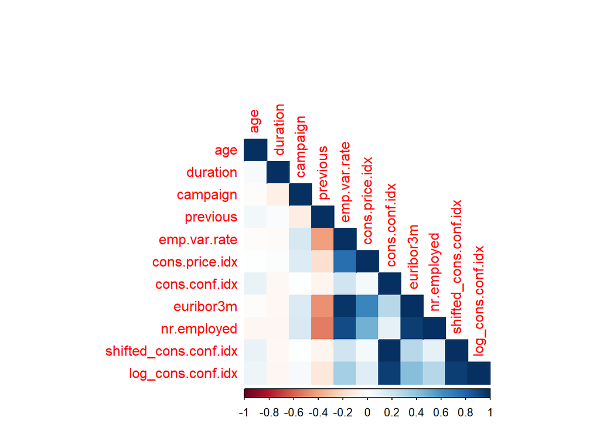

```r
mm_cor_matrix <- select_if(m_date, is.numeric)

# Compute the correlation matrix
cor_matrix <- cor(mm_cor_matrix)

# Plot the correlation matrix
corrplot(cor_matrix, method = "color", type = "lower", tl.cex = 1)
```

- Observation
  - Multicollinearity can be observed in redundant columns created during data pre-procesing
- shifted_cons.conf.idx,cons.conf.idx & pdays5 will be dropped

```r
#final_mm_dataset <- select(m_date,-c(shifted_cons.conf.idx,pdays5,cons.conf.idx,marital,poutcome))
final_mm_dataset <- select(m_date,-c(shifted_cons.conf.idx,pdays5,cons.conf.idx))
```

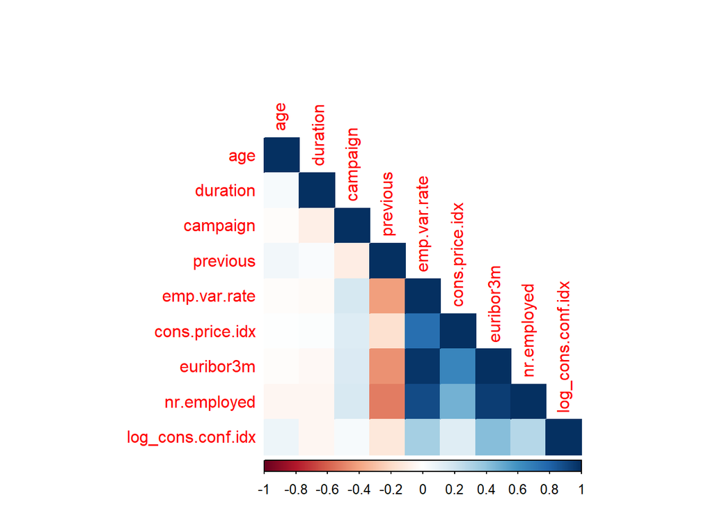

```r
df <- select_if(final_mm_dataset, is.numeric)

# Compute the correlation matrix
mm_cor_matrix <- cor(df)

# Plot the correlation matrix
corrplot(mm_cor_matrix, method = "color", type = "lower", tl.cex = 1)
```

### logistic modeling

- Note that we are using logisitic regression because our outcome is binary i.e yes or no

```r
library(caret)
```

- Spliting the dataset into a train set and a test set

```r
set.seed(350)
#partitioning the dataset i.e  70% train set and 30% for test set
mm_train = createDataPartition(y = final_mm_dataset$y, times = 1, p = 0.7, list = FALSE)
```

- Defining the training and testing datasets

```r
train_set = slice(final_mm_dataset, mm_train)
test_set = slice(final_mm_dataset, -mm_train)
```

- Creating a logistic regression model

```r
model <- glm(y ~ ., data = train_set, family = binomial)

# Print the summary of the model
summary(model)
```

```
##
## Call:
## glm(formula = y ~ ., family = binomial, data = train_set)
##
## Deviance Residuals:
##     Min       1Q   Median       3Q      Max
## -5.0927  -0.2810  -0.1650  -0.1039   2.9060
##
## Coefficients: (1 not defined because of singularities)
##                        Estimate Std. Error z value Pr(>|z|)
## (Intercept)           6.441e+01  1.500e+02   0.429  0.66765
## age                   6.630e-03  1.022e-02   0.649  0.51651
## jobblue-collar        9.245e-02  3.166e-01   0.292  0.77026
## jobentrepreneur      -1.259e+00  6.772e-01  -1.860  0.06295 .
## jobhousemaid          2.672e-01  5.445e-01   0.491  0.62356
## jobmanagement        -1.780e-02  3.469e-01  -0.051  0.95908
## jobretired            1.997e-01  4.303e-01   0.464  0.64251
## jobself-employed     -7.838e-01  5.403e-01  -1.451  0.14689
## jobservices          -1.728e-02  3.595e-01  -0.048  0.96167
## jobstudent           -7.994e-02  4.940e-01  -0.162  0.87144
## jobtechnician         2.058e-01  2.884e-01   0.714  0.47532
## jobunemployed         7.067e-01  4.552e-01   1.553  0.12051
## jobunknown           -2.183e+00  1.311e+00  -1.665  0.09591 .
## maritalmarried        1.837e-01  2.999e-01   0.612  0.54028
## maritalsingle         1.952e-01  3.442e-01   0.567  0.57056
## maritalunknown        5.258e-01  1.254e+00   0.419  0.67487
## kbasic.6y            -7.036e-02  4.867e-01  -0.145  0.88507
## kbasic.9y             1.106e-01  3.704e-01   0.299  0.76521
## khigh.school          1.823e-01  3.601e-01   0.506  0.61280
## killiterate          -1.456e+01  2.400e+03  -0.006  0.99516
## kprofessional.course  9.146e-02  4.053e-01   0.226  0.82146
## kuniversity.degree    1.219e-01  3.645e-01   0.334  0.73807
## kunknown              1.638e-01  4.946e-01   0.331  0.74057
## defaultunknown        1.052e-02  2.568e-01   0.041  0.96734
## defaultyes           -1.202e+01  2.400e+03  -0.005  0.99600
## housingunknown       -5.955e-01  6.227e-01  -0.956  0.33896
## housingyes           -1.554e-01  1.719e-01  -0.904  0.36594
## loanunknown                  NA         NA      NA       NA
## loanyes              -1.584e-01  2.312e-01  -0.685  0.49327
## contacttelephone     -6.727e-01  3.218e-01  -2.091  0.03656 *
```

[output cut: 38 more lines]

```
## emp.var.rate         -3.072e-01  6.017e-01  -0.511  0.60964
## cons.price.idx        3.202e-02  1.002e+00   0.032  0.97450
## euribor3m             3.230e-01  4.550e-01   0.710  0.47778
## nr.employed          -1.437e-02  1.163e-02  -1.235  0.21693
## log_cons.conf.idx     9.495e-02  2.477e-01   0.383  0.70143
## ---
## Signif. codes:  0 '***' 0.001 '**' 0.01 '*' 0.05 '.' 0.1 ' ' 1
##
## (Dispersion parameter for binomial family taken to be 1)
##
##     Null deviance: 1990.5  on 2870  degrees of freedom
## Residual deviance: 1068.9  on 2799  degrees of freedom
## AIC: 1212.9
##
## Number of Fisher Scoring iterations: 15
```

- Making predictions on the test set

```r
predictions <- predict(model, newdata = test_set, type = "response")
```

- Convert predictions to binary values (0 or 1) using a threshold of 0.5

```r
binary_predictions <- ifelse(predictions > 0.5, "yes", "no")
```

- Confusion matrix for the logisitic model

```r
heart_glm <- confusionMatrix(data = as.factor(binary_predictions), reference = as.factor(test_set$y), positive = "yes")
```

```r
heart_glm
```

```
## Confusion Matrix and Statistics
##
##           Reference
## Prediction   no  yes
##        no  1064   72
##        yes   30   63
##
##                Accuracy : 0.917
##                  95% CI : (0.9002, 0.9318)
##     No Information Rate : 0.8902
##     P-Value [Acc > NIR] : 0.001074
##
##                   Kappa : 0.5086
##
##  Mcnemar's Test P-Value : 4.916e-05
##
##             Sensitivity : 0.46667
##             Specificity : 0.97258
##          Pos Pred Value : 0.67742
##          Neg Pred Value : 0.93662
##              Prevalence : 0.10985
##          Detection Rate : 0.05126
##    Detection Prevalence : 0.07567
##       Balanced Accuracy : 0.71962
##
##        'Positive' Class : yes
##
```

- ROC construction using probabilities

```r
library(pROC)
roc_GLM <- roc(test_set$y, predictions)
print(roc_GLM)
```

```
##
## Call:
## roc.default(response = test_set$y, predictor = predictions)
##
## Data: predictions in 1094 controls (test_set$y no) < 135 cases (test_set$y yes).
## Area under the curve: 0.9091
```

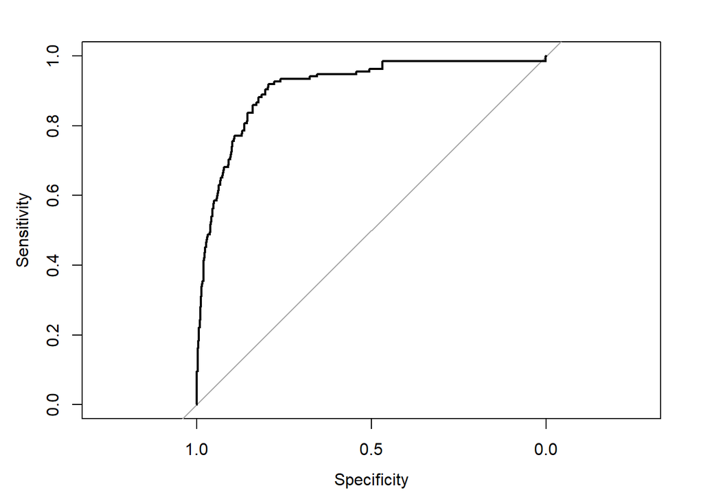

```r
plot(roc_GLM)
```